# Statistical Inference Project Part II

Patrick Bennett

September 26, 2015

## Basic summary and exploratory analysis of the data:

We will load the ToothGrowth dataset, take a look at some summary data, and use boxplots as an exploratory analysis tool to get a feel for the interaction between supp, dose, and len.

```r
library(ggplot2)
data(ToothGrowth)
summary(ToothGrowth)
```

```
##       len        supp         dose
##  Min.   : 4.20   OJ:30   Min.   :0.500
##  1st Qu.:13.07   VC:30   1st Qu.:0.500
##  Median :19.25           Median :1.000
##  Mean   :18.81           Mean   :1.167
##  3rd Qu.:25.27           3rd Qu.:2.000
##  Max.   :33.90           Max.   :2.000
```

```r
head(ToothGrowth)
```

```
##    len supp dose
## 1  4.2   VC  0.5
## 2 11.5   VC  0.5
## 3  7.3   VC  0.5
## 4  5.8   VC  0.5
## 5  6.4   VC  0.5
## 6 10.0   VC  0.5
```

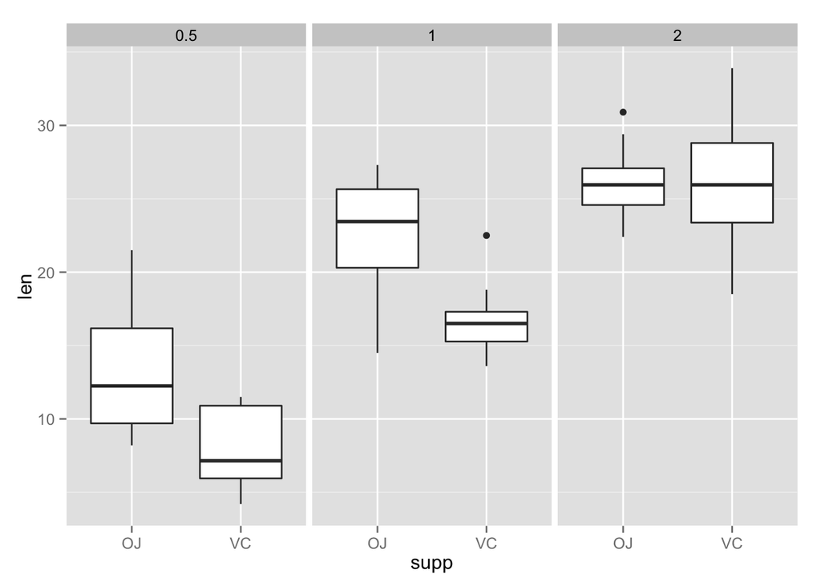

```r
ToothGrowth <- transform(ToothGrowth, dose=factor(dose))
qplot(supp, len, data=ToothGrowth, geom="boxplot", facets=.~dose)
```

## Preliminary hypotheses:

With effectiveness being measured through having a higher len, it would appear from the boxplots that perhaps there is a difference in effectiveness between supps, with OJ being superior to VC.

It would also appear that perhaps the higher dose levels are more effective than the lower ones.

## Statistical analysis of hypotheses & conclusions:

### Conclusion 1

Let’s test the first hypotehsis using a T-Test of the two supps:

```r
t.test(len~supp, data=ToothGrowth)
```

```
##
##  Welch Two Sample t-test
##
## data:  len by supp
## t = 1.9153, df = 55.309, p-value = 0.06063
## alternative hypothesis: true difference in means is not equal to 0
## 95 percent confidence interval:
##  -0.1710156  7.5710156
## sample estimates:
## mean in group OJ mean in group VC
##         20.66333         16.96333
```

The confidence interval encompasses 0, so we cannot reject the null hypothesis that there is no difference in effectiveness. Our first theory cannot be supported. We cannot statistically say that the OJ supp is more effective than the VC supp at achieving higher lens.

### Conclusion 2

Now, for the second hypothesis, let’s look at a T-Test comparing the 0.5 dose and the 2.0 dose. We will subset the data to help us with this.

```r
dosecompare = subset(ToothGrowth, dose %in% c(0.5,2))
t.test(len~dose, data=dosecompare)
```

```
##
##  Welch Two Sample t-test
##
## data:  len by dose
## t = -11.799, df = 36.883, p-value = 4.398e-14
## alternative hypothesis: true difference in means is not equal to 0
## 95 percent confidence interval:
##  -18.15617 -12.83383
## sample estimates:
## mean in group 0.5   mean in group 2
##            10.605            26.100
```

In this case, the confidence interval does not encompass 0, and the p-value is well below 0.05, indicating that we can reject the null hypothesis and conclude that the dose of 2.0 has statistically higher lengths than the dose of 0.5. Higher doses are more effective at achieving higher lengths (as between dose 2.0 and dose 0.5).